# Report1

denizsevde

3 Nisan 2019

## R Project Report

As a group we are making a project about Vedat Milor and restourants which he recommend. He has articles about food critics and 3 different areas for his articles. Which are Hürriyet.com, Gastromondiale and Mizanplas. He is a writer and TV Host and an academician.

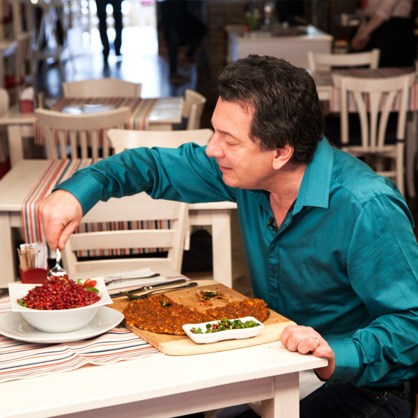

Here is Vedat Milor

## About the project

In this project we are getting data from different articles which Vedat Milor published on different areas. From this restourant information, we are searching about them on foursquare.com and we get their foursquare id’s for each. We wrote a code for getting details. For running this code getting restaurant data and details we have subscription on developer.Foursquare.com and we are using free version of it. With this membership we have client id and client secret. So with using client id and client secret we are able to get data wih our R code from foursquare. with these data we are aim to get restourant information and analize it. At the end of the project we are planning to show at least 200 restourants from different places with their locations, types, points and popularity. We are going to analyse and visualize it with graphs and diagrams. We will compare them each other and identify best options for each type of restourants.

## What we did?

Like We mentioned before we made an excel sheet which involves 60 restaurants which are recomended by Vedat Milor and searched about their foursquare id. Than wrote a code that is :

```r
library(tidyverse)
library(jsonlite)
library(lubridate)
raw_data <- readxl::read_excel("C:\\Users\\Deniz\\Desktop\\VedatMilor-R.xlsx") %>% filter(!is.na(foursquare_id))
```

```
## * `` -> ...1
```

```r
get_place_details_from_id <- function(place_id="5bd03ceae075500038a886e9",client_id,client_key){

  the_url <- paste0("https://api.foursquare.com/v2/venues/", place_id,"?client_id=",client_id,"&client_secret=",client_key,"&v=",format(lubridate::today(),"%Y%m%d"))

  res <- jsonlite::fromJSON(the_url)
  place_data <-
    tibble(
      id = place_id,
      name = res$response$venue$name,
      lat = res$response$venue$location$lat,
      lng = res$response$venue$location$lng,
      country = res$response$venue$location$country,
      city = ifelse(is.null(res$response$venue$location$city),"",res$response$venue$location$city),
      state = ifelse(is.null(res$response$venue$location$state),"",res$response$venue$location$state),
      fsq_rating = ifelse(is.null(res$response$venue$rating),-50,res$response$venue$rating)

    )

  place_categories <- res$response$venue$categories
  return(list(data=place_data,categories=place_categories,raw_result=res))
}

placedata=tibble()
for(i in 1:nrow(raw_data)) {
  print(i)
  dd <- get_place_details_from_id(raw_data$foursquare_id[i], client_id = "ER2Q0HIICA25JOPBBNWV205ZSVQKODJAPSESAQJMILD2LPBC", client_key = "DPZBQBYW2NK0RC2V4FW4SOLCAYHPBCMFMQDAOAAL2JE11MWE")
placedata=bind_rows(placedata, dd$data)

}
```

```
## [1] 1
## [1] 2
## [1] 3
## [1] 4
## [1] 5
## [1] 6
## [1] 7
## [1] 8
## [1] 9
## [1] 10
## [1] 11
## [1] 12
## [1] 13
## [1] 14
## [1] 15
```

[output cut: 17 more lines]

```r
save(placedata,file="day1.RData")
load("day1.RData")
```

## What we will do?

With using this data, we will analize the restaurants, their locations, where Vedat Milor eats, what he eats, what he recommends and what are the view of foursquare users about them. We check and compare these data. We will mine data and analize it. We will also visualize the data with graphs and diagrams. We will support it with comparing them each other and identifing best options for each type of restourants.